# MB5370 Module 04. Data Science in R 2

## Legends and Color Schemes

To control the overall position of the legend, you need to use a theme() setting

### Default legend setting (right)

```r
base <- ggplot(mpg, aes(displ, hwy)) +
  geom_point(aes(color = class))

base + theme(legend.position = "right")
```

[output not shown]

### Legend to the bottom

```r
  base + theme(legend.position = "bottom")
```

[figure not shown]

### Legend to the top

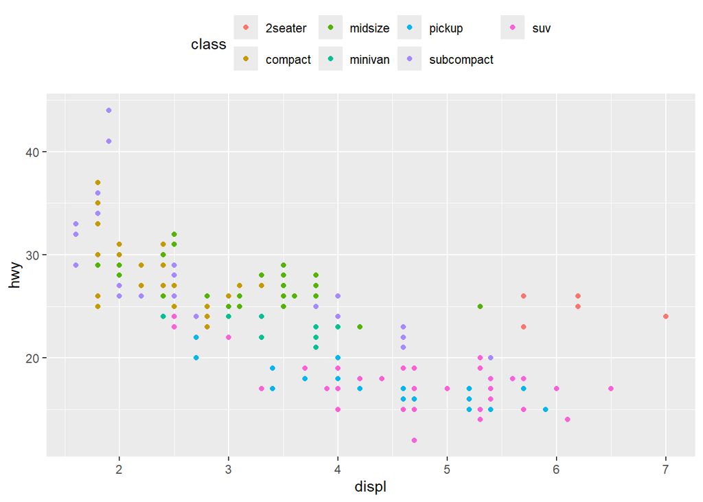

```r
base + theme(legend.position = "top")
```

### Legend to the left

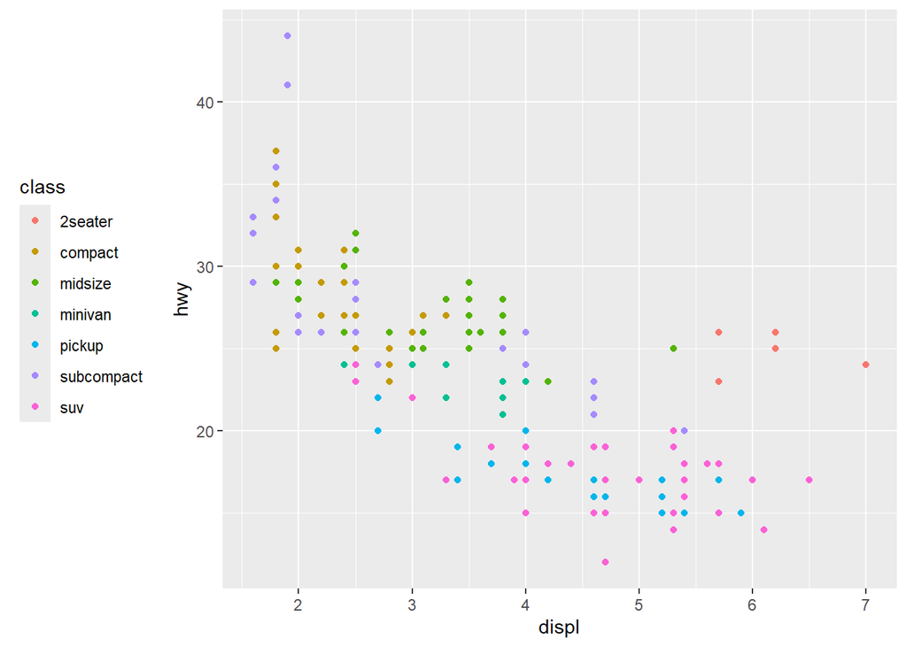

```r
base + theme(legend.position = "left")
```

### You can also use legend.position = “none” to suppress the display of the legend altogether!

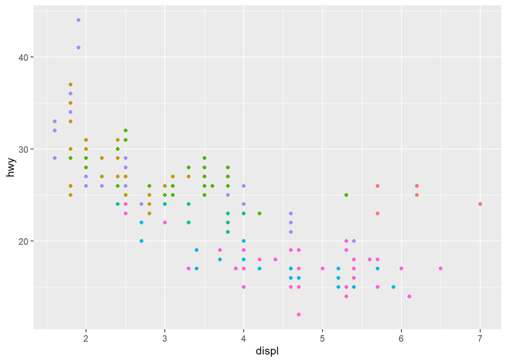

```r
base + theme(legend.position = "none")
```

## Replacing a Scale

There are two types of scales you’re mostly likely to want to switch out: continuous position scales and color scales.

It’s very useful to plot transformations of your variables. As we’ve seen in diamond prices (Workshop 1) it’s easier to see the precise relationship between carat and price if we log transform them using a ggplot2 function for scale precisely for this purpose.

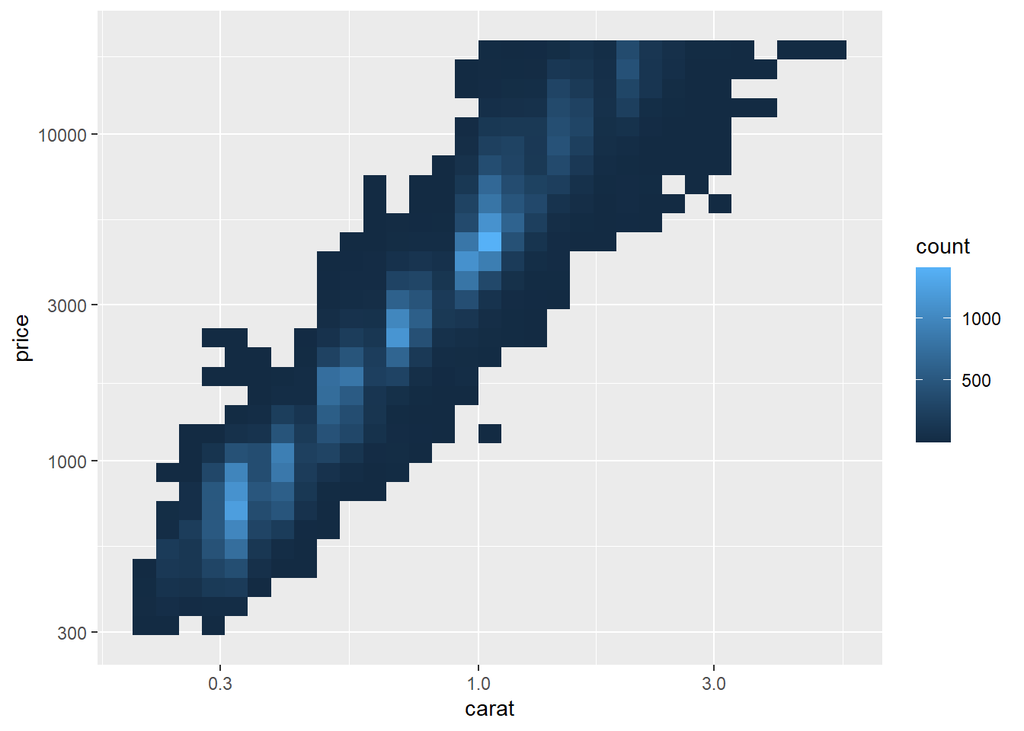

```r
ggplot(diamonds, aes(carat, price)) +
  geom_bin2d() +
  scale_x_log10() +
  scale_y_log10()
```

The color scale is very popular when visualizing data. This is one of the most important changes you can make to a base ggplot

### Set color by drv

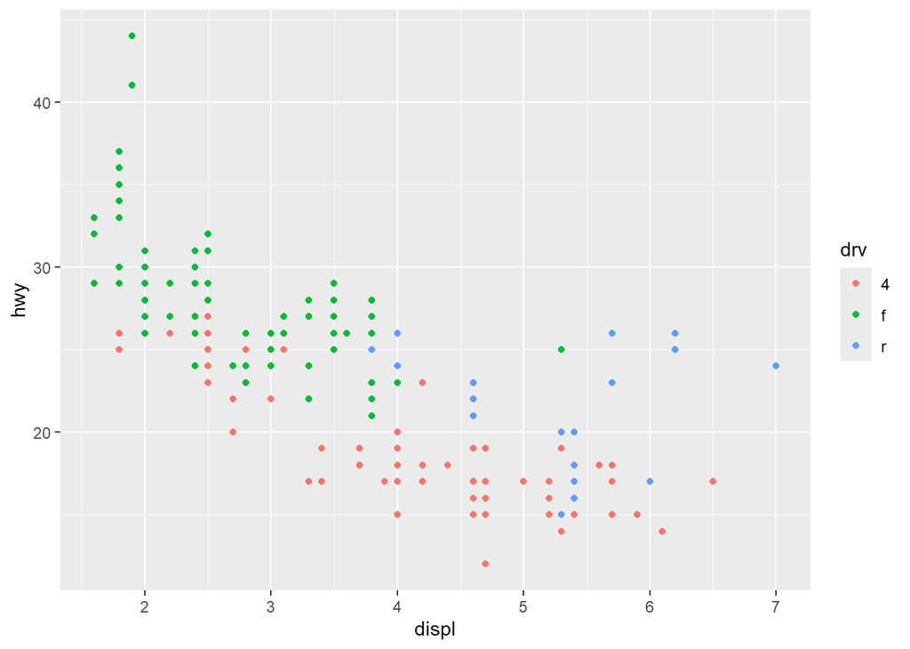

```r
ggplot(mpg, aes(displ, hwy)) +
  geom_point(aes(color = drv))
```

### Set color by drv using a pre-made palette

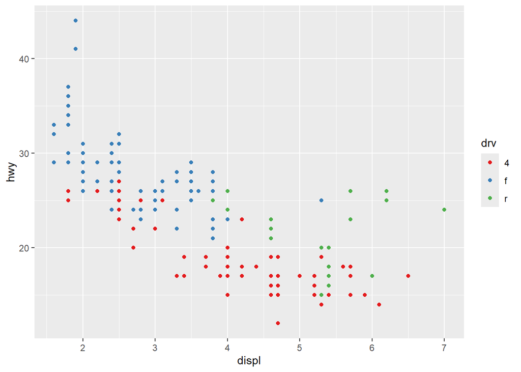

```r
ggplot(mpg, aes(displ, hwy)) +
  geom_point(aes(color = drv)) +
  scale_color_brewer(palette = "Set1")
```

If there are just a few colors, you can add a redundant shape mapping. This will also help ensure your plot is interpretable in black and white.

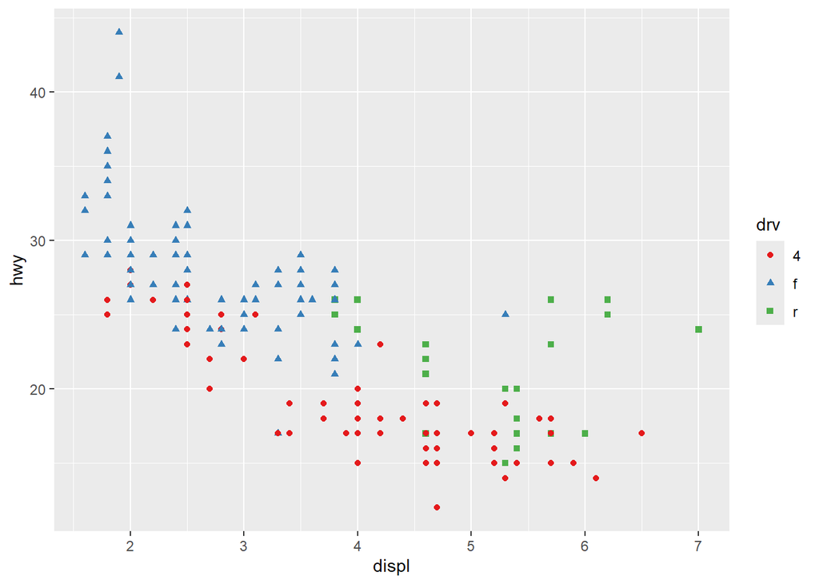

```r
ggplot(mpg, aes(displ, hwy)) +
  geom_point(aes(color = drv, shape = drv)) +
  scale_color_brewer(palette = "Set1")
```

The ColorBrewer scales are documented online at http://colorbrewer2.org/. There are a range of different color schemes you can import such as this, so read more about them in the ggplot2 cookbook: http://www.cookbook-r.com/Graphs/Colors_(ggplot2)/

When you have predefined colors you want to use you can set them yourself, using scale_color_manual()

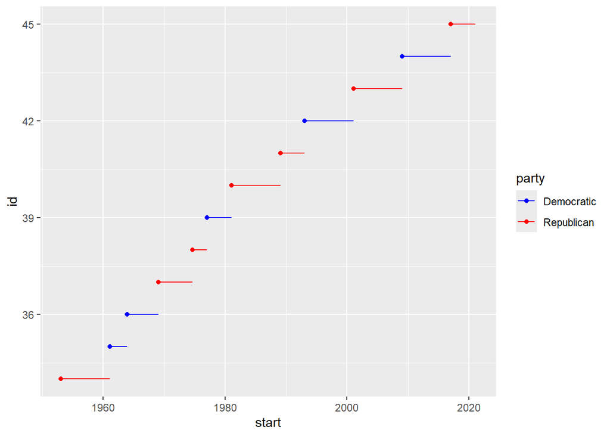

```r
presidential %>%
  mutate(id = 33 + row_number()) %>%
  ggplot(aes(start, id, color = party)) +
  geom_point() +
  geom_segment(aes(xend = end, yend = id)) +
  scale_color_manual(values = c(Republican = "red", Democratic = "blue"))
```

## Popular Color Package

### Install and load packages

Because I have already installed these packages, I have hashtagged the code out.

```r
# install.packages("viridis")
# install.packages("hexbin")
library(viridis)
library(hexbin)
```

### Create a tibble

```r
df <- tibble(
  x = rnorm(10000),
  y = rnorm(10000)
) # Making a fake data set to plot using this function
```

### Plot the tibble

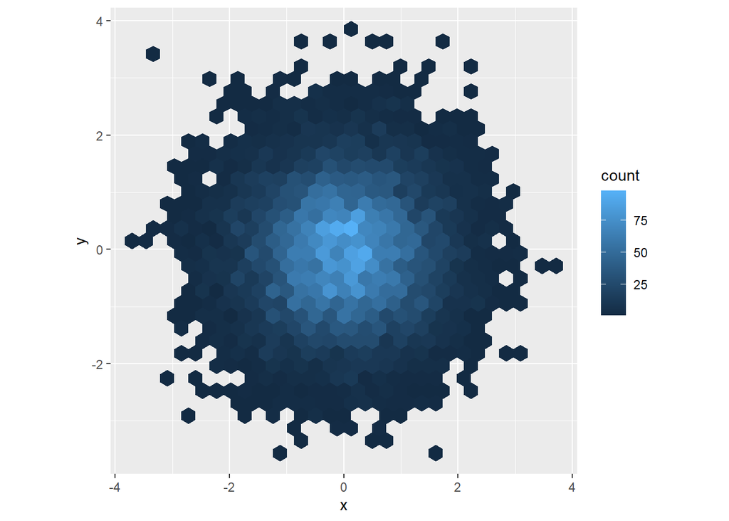

```r
ggplot(df, aes(x, y)) +
  geom_hex() + # New geom!
  coord_fixed()
```

### Plot the tibble using the color package

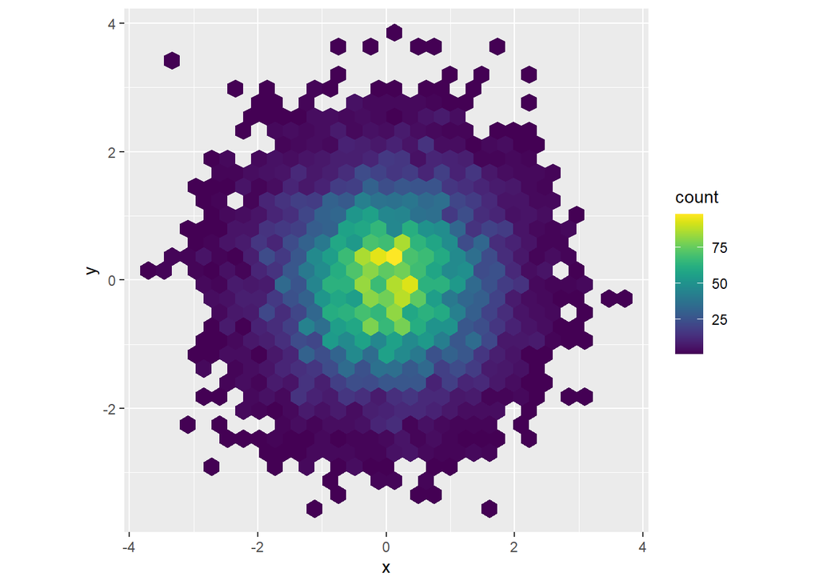

```r
ggplot(df, aes(x, y)) +
  geom_hex() +
  viridis::scale_fill_viridis() +
  coord_fixed()
```

## Themes

Themes allow you to change some or all of the non-data elements of your plot with a theme.

ggplot2 has eight themes by default. Many more are included in add-on packages like ggthemes (https://github.com/jrnold/ggthemes), by Jeffrey Arnold.

### The classic dark-on-light ggplot2 theme. May work better for presentations displayed with a projector.

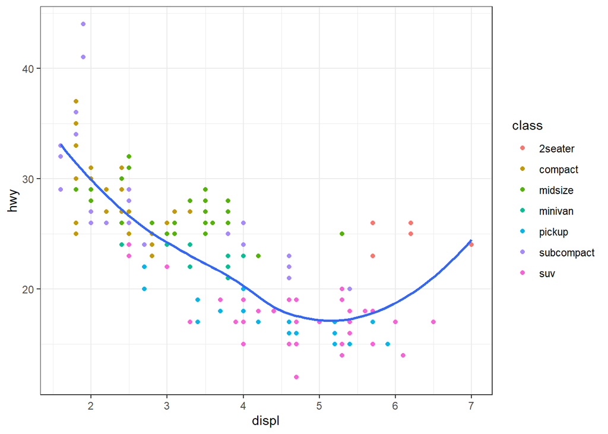

```r
ggplot(mpg, aes(displ, hwy)) +
  geom_point(aes(color = class)) +
  geom_smooth(se = FALSE) +
  theme_bw()
```

### Light theme. Makes the background all white with larger cells for the grid. Uses light grey lines and axes to direct more attention towards the data.

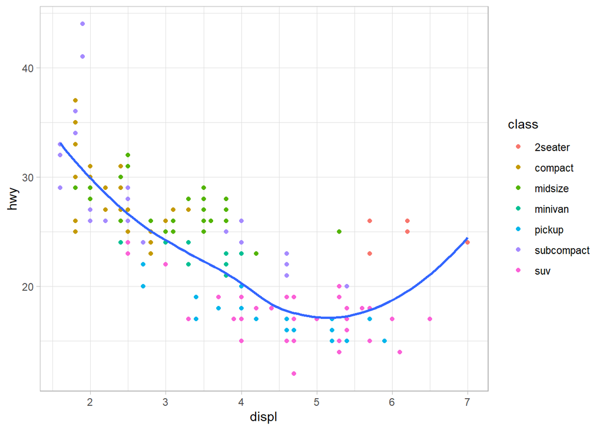

```r
ggplot(mpg, aes(displ, hwy)) +
  geom_point(aes(color = class)) +
  geom_smooth(se = FALSE) +
  theme_light()
```

### A classic-looking theme, with x and y axis lines and no gridlines.

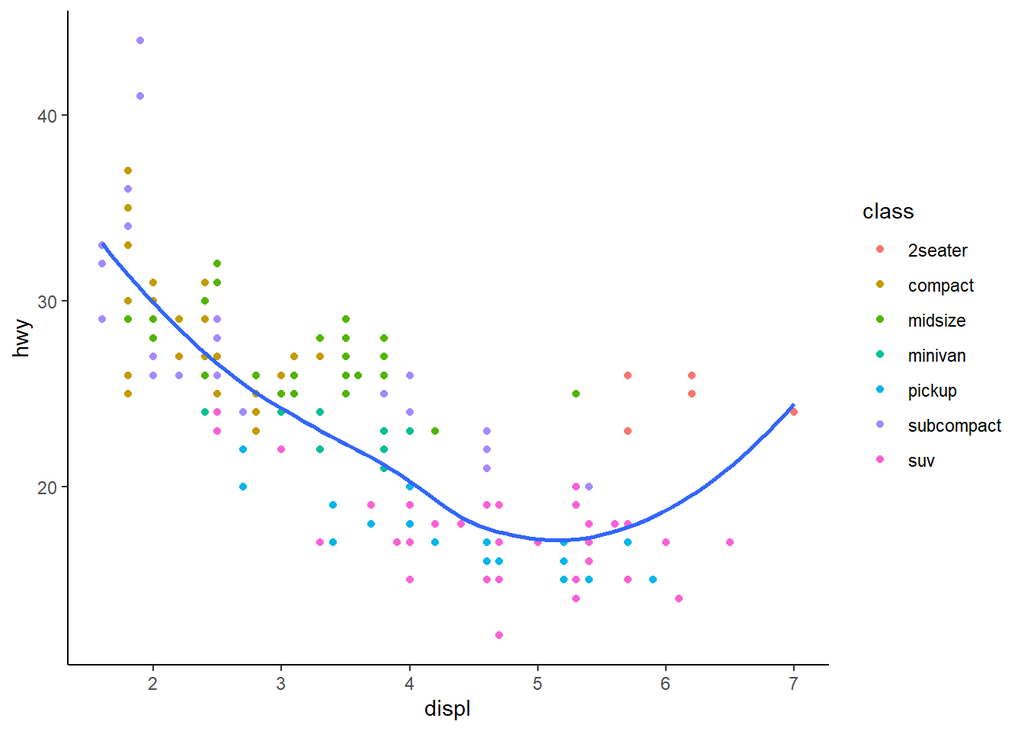

```r
ggplot(mpg, aes(displ, hwy)) +
  geom_point(aes(color = class)) +
  geom_smooth(se = FALSE) +
  theme_classic()
```

### The dark cousin of theme_light(), with similar line sizes but a dark background. Useful to make thin coloured lines pop out.

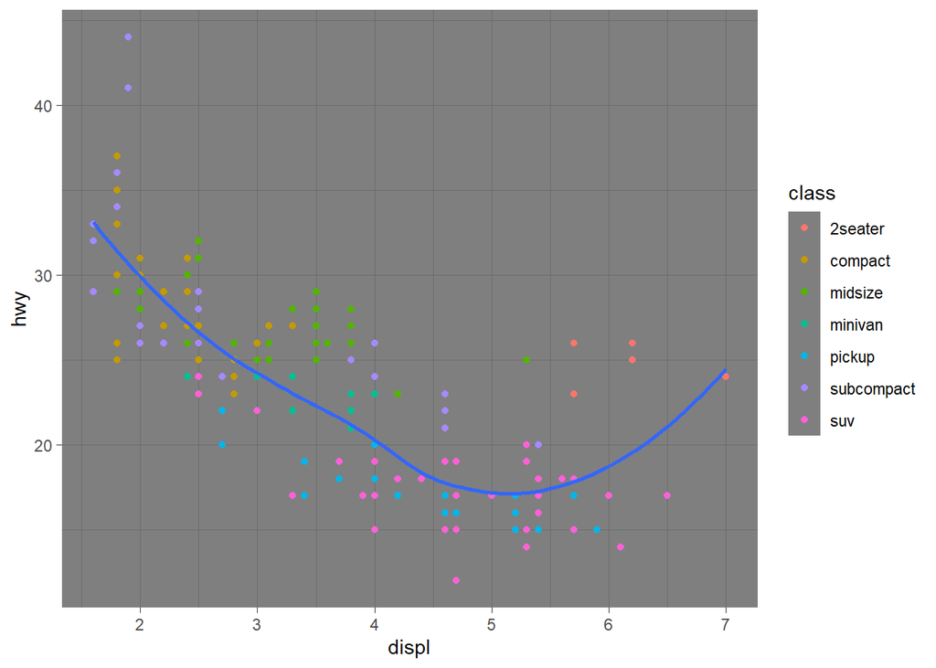

```r
ggplot(mpg, aes(displ, hwy)) +
  geom_point(aes(color = class)) +
  geom_smooth(se = FALSE) +
  theme_dark()
```